**PROJECT 1 REPORT**  
**ALY6010 22939**  
Akshay Kirit Kalavadia  
Prof. Dee Chiluiza, PhD  
03/10/2021

**INTRODUCTION**

Coronavirus pandemic has taken a hit at Global economy in 2020. Automobile industry is one of the sector that was affected the most. There was a downward trend in car sales. It fell under 64 million automobiles against predicted sales of 80 million, i.e. 25% below expectations in the year 2020 (Wagner, 2021). Sales in 2020 were 15% below the sales achieved in 2019.

In India, vehicle market is expected to see drastic increase in demand after two years of drop in sales of cars in 2019 and 2020. Experts from many analytics firm are predicting that the growth of sale of vehicles will be between 23% to 32% in 2021 (Thakkar,2021). Highest growth in India was 30% in 2010.

**Discrete and Continuous Probability Distribution** helps us to determine the best course of action by using our judgment in daily life (Tucker, 2020). For example, in the above topic, probability of car sales in 2021 will help companies with planning their production capacity, schedule and the resources required for the same.

**Dataset**: In this assignment we are using dataset of car sale in India from 1998 to 2019. The dataset includes different car model at different locations in India with different ownership with various prices. It also provides us information about the seating capacity, efficiency, size of the engine(in Cubic Centimeter) and brake horsepower (BHP). Following summary of the dataset will help us understand data properly at first glance.

```r
summary(carset1)
```

```
##     Model                 Location         Year            Km
##  Length:5844        Mumbai    : 773   2014   : 792   Min.   :   171
##  Class :character   Hyderabad : 713   2015   : 738   1st Qu.: 33493
##  Mode  :character   Kochi     : 643   2016   : 735   Median : 52564
##                     Coimbatore: 626   2013   : 637   Mean   : 57078
##                     Pune      : 590   2017   : 586   3rd Qu.: 72414
##                     Delhi     : 543   2012   : 555   Max.   :420000
##                     (Other)   :1956   (Other):1801
##      FuelType       Transmission     Owner        Efficiency      Engine_cc
##  CNG     :  55   Automatic:1681   First :4818   Min.   : 8.00   Min.   : 600
##  Diesel  :3134   Manual   :4163   Fourth:   7   1st Qu.:16.00   1st Qu.:1200
##  Gasoline:2645                    Second: 918   Median :18.00   Median :1400
##  LPG     :  10                    Third : 101   Mean   :17.94   Mean   :1607
##                                                 3rd Qu.:22.00   3rd Qu.:2000
##                                                 Max.   :30.00   Max.   :5000
##
##    Power_bhp         Seats        Price_US_Dollars
##  Min.   : 50.0   Min.   : 2.000   Min.   :   618
##  1st Qu.:100.0   1st Qu.: 5.000   1st Qu.:  4938
##  Median :100.0   Median : 5.000   Median :  8009
##  Mean   :139.3   Mean   : 5.171   Mean   : 13401
##  3rd Qu.:150.0   3rd Qu.: 5.000   3rd Qu.: 14039
##  Max.   :600.0   Max.   :10.000   Max.   :224624
##
```

**Analysis Section**

**Part-1**

**Task 3.1**: Prepare a bar plot to show the counts of variable efficiency.

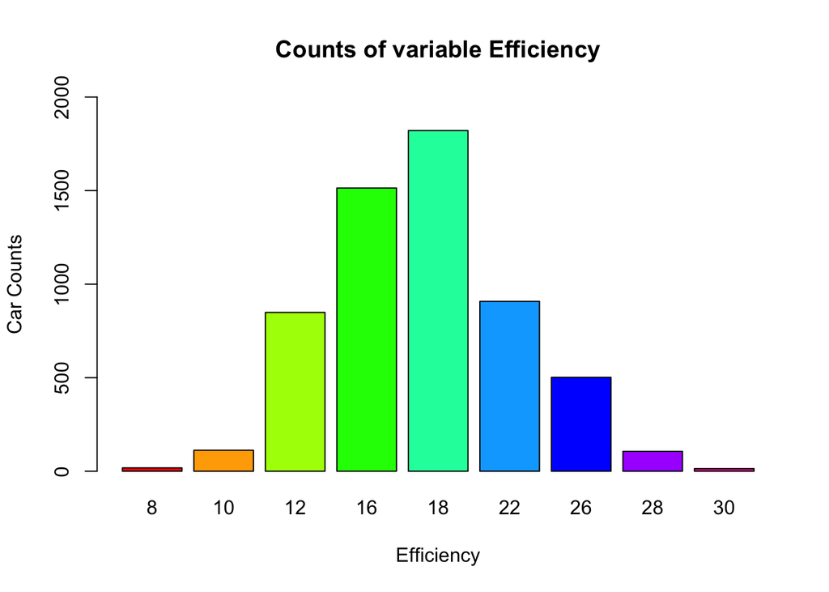

```r
barplot(table(carset1$Efficiency),
        main = "Counts of variable Efficiency",
        xlab = "Efficiency",
        ylab = "Car Counts",
        ylim = c(0,2000),
        col = rainbow(9))
```

**Observations**: In the above graph, X-axis represents Efficiency and Y-axis represents Car Counts (Frequency). The shape of distribution in the above graph is Bell-Shaped (Bluman, 2018). It is a Normally Distributed graph with approximate same mean, median and mode value of **18** at the center. All the values are mostly distributed evenly on both the sides of the mean. Maximum efficiency variable is located on the right at the right of mean at 30 and minimum efficiency variable is located at the left of mean at 8.

**Task 3.2**: Prepare a bar plot to show the counts of variable engine(cc).

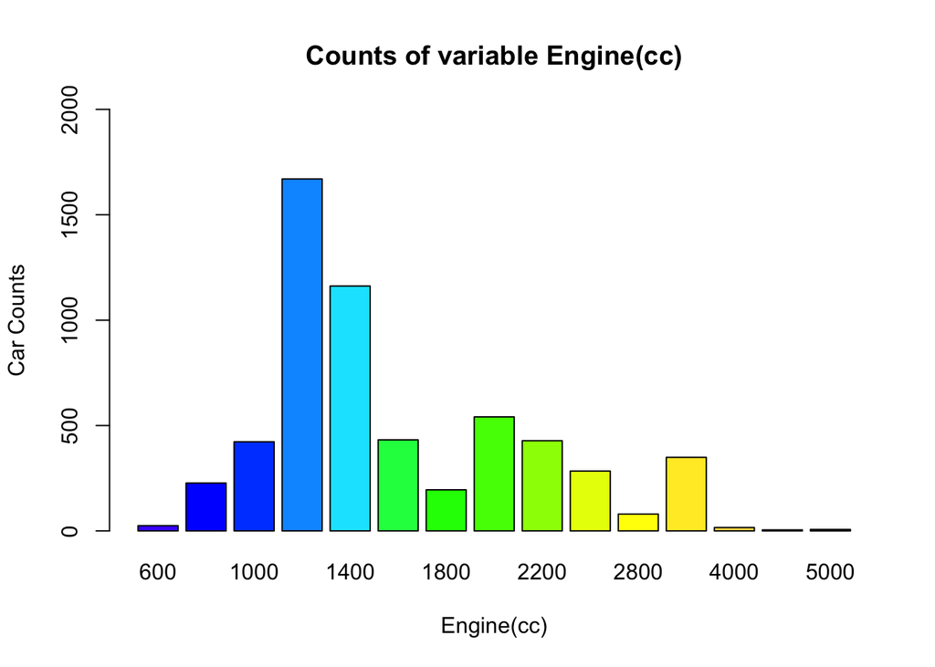

```r
barplot(table(carset1$Engine_cc),
        main = "Counts of variable Engine(cc)",
        xlab = "Engine(cc)",
        ylab = "Car Counts",
        ylim = c(0,2000),
        col = topo.colors(15))
```

**Task 3.3**: Prepare a bar plot to show the counts of variable power(bph).

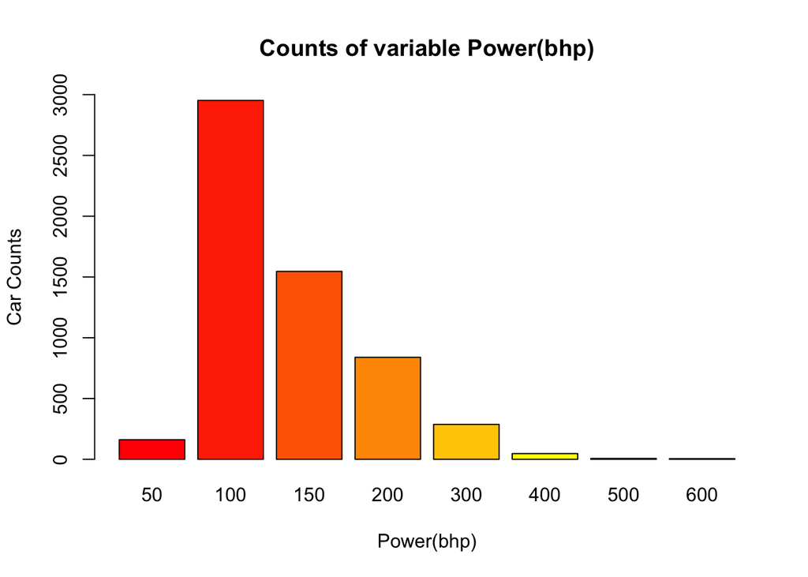

```r
barplot(table(carset1$Power_bhp),
        main = "Counts of variable Power(bhp)",
        xlab = "Power(bhp)",
        ylab = "Car Counts",
        ylim = c(0,3000),
        col = heat.colors(8))
```

**Observations**: In the above graph, X-axis represents Power(bhp) and Y-axis represents Car Counts (Frequency). The shape of distribution in the above graph is Positively or Right-Skewed shaped (Bluman, 2018). The mean of the dataset is 139.3. Both Median and Mode are located on the left of mean at 100 bhp with 2952 observations. Only 5 cars in the dataset has 600 bhp.

**Task 3.4**: Prepare a bar plot to show the counts of variable seats.

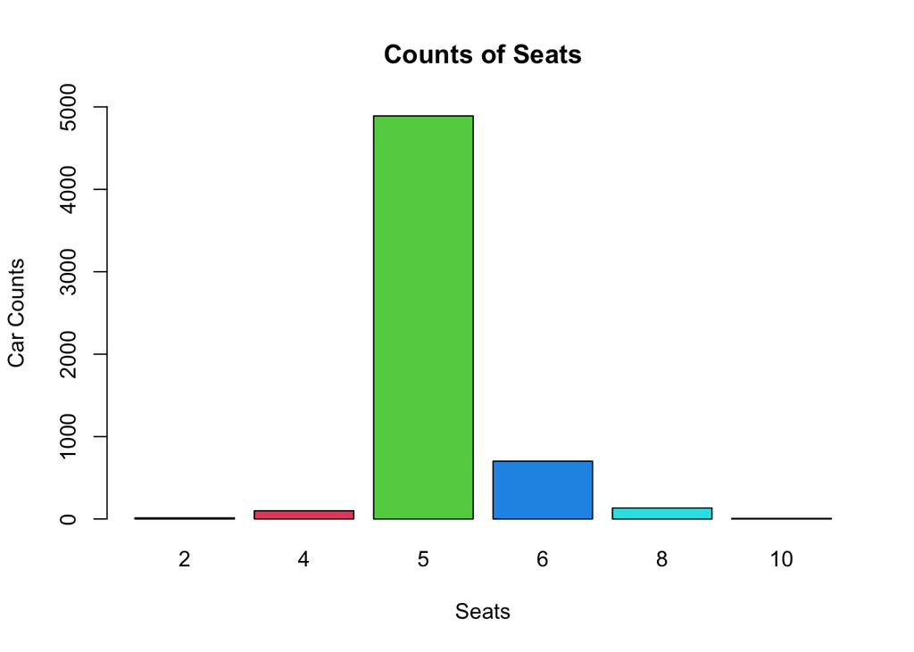

```r
barplot(table(carset1$Seats),
        main = "Counts of Seats",
        xlab = "Seats",
        ylab = "Car Counts",
        ylim = c(0,5000),
        col = 1:6)
```

**Observations**: In the above graph, X-axis represents Seats and Y-axis represents Car Counts (Frequency). The shape of distribution in the above graph is Bell-Shaped (Bluman, 2018). It is a Normally Distributed graph with approximate same mean, median and mode value of **5** at the center. It can be inferred from the graph that most (4891) car users prefer 5 seating cars in India and hence all car manufacturing companies produce 5-seater cars the most. Seats graph has the least spread concentrated at the center.

**Part-2**

**Task 3.5**: Prepare a table to display individual probabilities of all values inside variable Efficiency.

```r
library(DT)
library(rio)
library(dbplyr)

carset1_efficiency<-as.data.frame(table(carset1$Efficiency))
Probablility_efficiency<-as.data.frame(table(carset1$Efficiency)/sum(carset1_efficiency$Freq))
colnames(Probablility_efficiency)<- c("Efficiency","Probability")
Probablility_efficiency$Probability<-round(Probablility_efficiency$Probability,4)
datatable(Probablility_efficiency, options = list(paging = F), rownames = F)
```

| Efficiency | Probability |
| --- | --- |
| 8 | 0.0031 |
| 10 | 0.0192 |
| 12 | 0.1453 |
| 16 | 0.2591 |
| 18 | 0.3116 |
| 22 | 0.1554 |
| 26 | 0.0859 |
| 28 | 0.0181 |
| 30 | 0.0024 |

**Task 3.6**: Prepare a table to display individual probabilities of all values inside variable Engine(cc).

```r
carset1_engine<-as.data.frame(table(carset1$Engine_cc))
Probablility_engine<-as.data.frame(table(carset1$Engine_cc)/sum(carset1_engine$Freq))
colnames(Probablility_engine)<- c("Engine (cc)","Probability")
Probablility_engine$Probability<-round(Probablility_engine$Probability,4)
datatable(Probablility_engine, options = list(paging = F), rownames = F)
```

| Engine (cc) | Probability |
| --- | --- |
| 600 | 0.0043 |
| 800 | 0.0388 |
| 1000 | 0.0724 |
| 1200 | 0.2858 |
| 1400 | 0.1988 |
| 1600 | 0.0739 |
| 1800 | 0.0334 |
| 2000 | 0.0926 |
| 2200 | 0.0732 |
| 2400 | 0.0486 |

[output cut: 5 more lines]

**Task 3.7**: Prepare a table to display individual probabilities of all values inside variable Power(bph).

```r
carset1_Power_bhp<-as.data.frame(table(carset1$Power_bhp))
Probablility_Power_bhp<-as.data.frame(table(carset1$Power_bhp)/sum(carset1_Power_bhp$Freq))
colnames(Probablility_Power_bhp)<- c("Power (bhp)","Probability")
Probablility_Power_bhp$Probability<-round(Probablility_Power_bhp$Probability,4)
datatable(Probablility_Power_bhp, options = list(paging = F), rownames = F)
```

| Power (bhp) | Probability |
| --- | --- |
| 50 | 0.0275 |
| 100 | 0.5051 |
| 150 | 0.2645 |
| 200 | 0.1436 |
| 300 | 0.0491 |
| 400 | 0.008 |
| 500 | 0.0012 |
| 600 | 0.0009 |

**Task 3.8**: Prepare a table to display individual probabilities of all values inside variable Seats.

```r
carset1_Seats<-as.data.frame(table(carset1$Seats))
Probablility_Seats<-as.data.frame(table(carset1$Seats)/sum(carset1_Seats$Freq))
colnames(Probablility_Seats)<- c("Seats","Probability")
Probablility_Seats$Probability<-round(Probablility_Seats$Probability,4)
datatable(Probablility_Seats,options = list(paging = F), rownames = F)
```

| Seats | Probability |
| --- | --- |
| 2 | 0.0022 |
| 4 | 0.0169 |
| 5 | 0.8369 |
| 6 | 0.12 |
| 8 | 0.0228 |
| 10 | 0.0012 |

**Part-3**

**Task 3.9**: Prepare a histogram and a box plot to display distribution of variable kilometers.

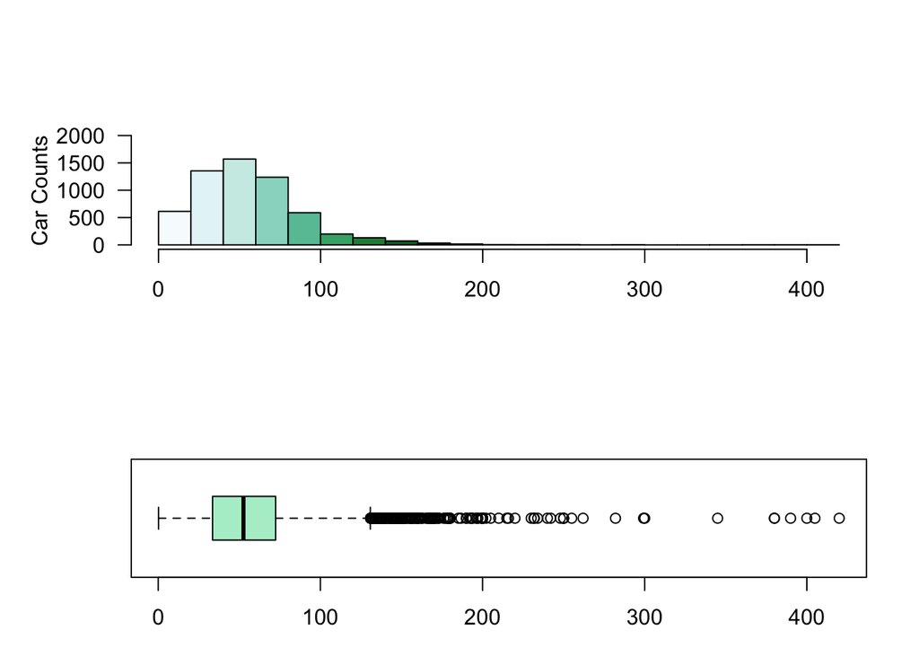

```r
par(mfrow = c(2,1), mai = c(0.6,1,1,0.4))
hist(carset1$Km/1000,
     breaks = 25,
     main = NA,
     ylim=c(0,2000),
     col = brewer.pal((9),"BuGn"),
     las=1,
     ylab = "Car Counts"
     )

boxplot(carset1$Km/1000,
        horizontal = TRUE,
        main = NA,
        col = "#B2EED0")
```

**Task 3.10**: Prepare a histogram and a box plot to display distribution of variable price.

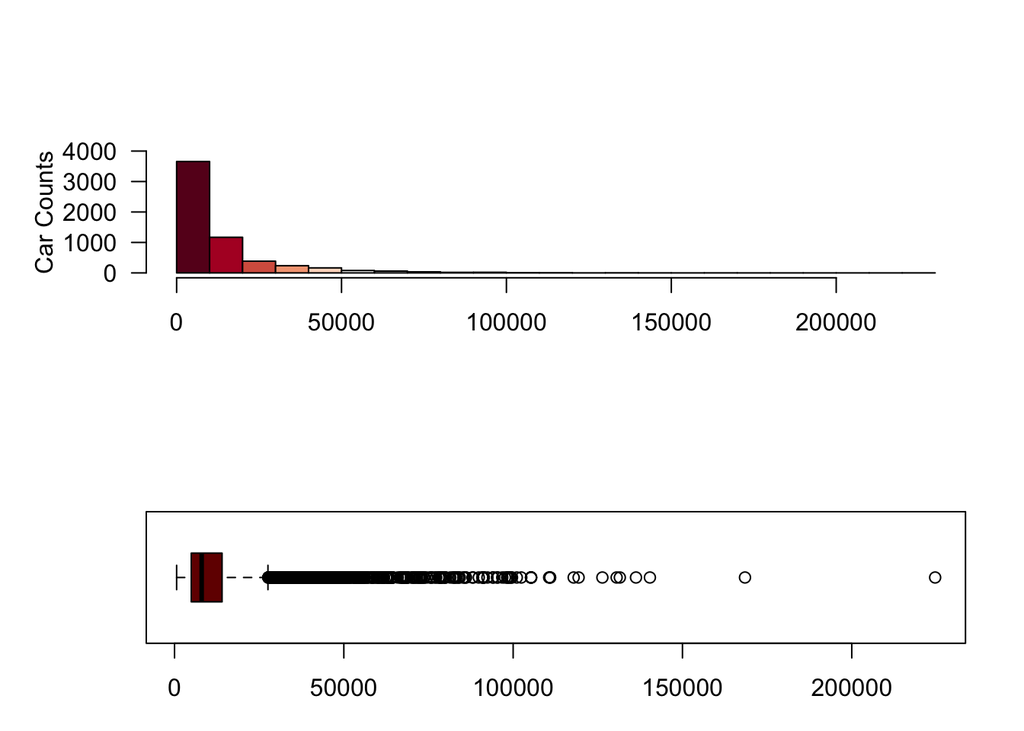

```r
par(mfrow = c(2,1), mai = c(0.6,1,1,0.4))
hist(carset1$Price_US_Dollars,
     breaks = 25,
     main = NA,
     ylim=c(0,4000),
     col = brewer.pal((11),"RdGy"),
     las=1,
     ylab = "Car Counts")

boxplot(carset1$Price_US_Dollars,
        horizontal = TRUE,
        main = NA,
        col = rgb(.45, .0, .0))
```

**Conclusions**

Car sales industry involves a lot of analysis. While looking at the dataset we can infer many observations which will help us work in the direction of effective manufacturing, sales and marketing. In the car sales dataset, we can observe that most customers in India prefer cars with efficiency of 18, engine with 1200cc and 100 braking horse power and 5 seats. It is also inferred from the data that maximum car sold were first hand ownership. Customers in India prefer manual over automatic transmission.

In this Project, I learned how to use RMarkdown to generate reports along with Rscript, better presentation of table with the help of datatable() and how to stack two graphs in a group for better visualization and comparison. I also learned about different shapes of distributions like Normal distribution, Positively-Skewed, Negatively-Skewed and the positions of mean, median and mode in each distribution.

**Reference**

Bluman, A. G. (2018). Elementary statistics: A step by step approach. New York, NY: McGraw-Hill Education.

Culver, M. December 17, 2020. Global Auto Sales Expected to Gain Momentum Next Year; 83.4 Million Light Vehicles to Be Sold In 2021, According to IHS Markit. Business Wire. Retrieved March 09, 2021, from https://www.businesswire.com/news/home/20201217005798/en/Global-Auto-Sales-Expected-to-Gain-Momentum-Next-Year-83.4-Million-Light-Vehicles-to-Be-Sold-In-2021-According-to-IHS-Markit

Thakkar, K. (2021, January 11). Indian car market may post Record 30% growth in 2021 on low base - Et auto. Retrieved March 09, 2021, from https://auto.economictimes.indiatimes.com/news/passenger-vehicle/cars/indian-car-market-may-post-record-30-growth-in-2021-on-low-base/80218106

Tucker, K. (2020, December 21). Examples of real life probability. Retrieved March 12, 2021, from https://sciencing.com/examples-of-real-life-probability-12746354.html

Wagner, I. (2021, February 05). Topic: Automotive industry worldwide. Retrieved March 09, 2021, from https://www.statista.com/topics/1487/automotive-industry/

**Appendix**

An R Markdown file has been attached to this report. The name of the file is Project1_akshay.Rmd .